[figure not shown]

# CSCI 416-01/516-01, Fundamentals of AI/ML

# Fall 2025

# A CNN for the MNIST digit dataset

## Credit where credit is due

Much of the code in the last section of this notebook was taken from notebooks that accompany the first edition of Chollet's *Deep Learning with Python*.

# Preamble

```python
import numpy as np
import tensorflow as tf
```

```python
print(tf.__version__)
```

```
2.20.0
```

```python
# Try to make the randomness repeatable.
np.random.seed(42)
tf.random.set_seed(54)
```

# Read and preprocess the data

```python
from tensorflow.keras.datasets import mnist

(X_train, y_train), (X_test, y_test) = mnist.load_data()

X_train = X_train.reshape((60000, 28, 28, 1))
X_test = X_test.reshape((10000, 28, 28, 1))
```

On a mad whim, let's encode the class labels using one-hot encoding. Here are the original labels:

```python
print(y_train)
print(y_test)
```

```
[5 0 4 ... 5 6 8]
[7 2 1 ... 4 5 6]
```

Now we transmogrify them:

```python
from tensorflow.keras.utils import to_categorical

y_train = to_categorical(y_train)
y_test  = to_categorical(y_test)
```

```python
print(y_train)
print(y_test)
```

```
[[0. 0. 0. ... 0. 0. 0.]
 [1. 0. 0. ... 0. 0. 0.]
 [0. 0. 0. ... 0. 0. 0.]
 ...
 [0. 0. 0. ... 0. 0. 0.]
 [0. 0. 0. ... 0. 0. 0.]
 [0. 0. 0. ... 0. 1. 0.]]
[[0. 0. 0. ... 1. 0. 0.]
 [0. 0. 1. ... 0. 0. 0.]
 [0. 1. 0. ... 0. 0. 0.]
 ...
 [0. 0. 0. ... 0. 0. 0.]
 [0. 0. 0. ... 0. 0. 0.]
 [0. 0. 0. ... 0. 0. 0.]]
```

For each label we have created a vector of length 10 with one entry for each class. All entries are $0$ except for a $1$ in the component representing the class.

For instance, the first image in the training set is a $5$, so there is a $1$ in component $5$:

```python
print(y_train[0])
```

```
[0. 0. 0. 0. 0. 1. 0. 0. 0. 0.]
```

# Build a CNN

We then alternate convolutional layers with pooling layers; this is a common architecture.

## Pooling layers

**Pooling layers** downsample their input. They do so by decomposing the input into blocks of specified size and keep only part of the information about the block.

[Max pooling layers](https://www.tensorflow.org/api_docs/python/tf/keras/layers/MaxPool2D) only the maximum value for each block.

[Average pooling layers](https://www.tensorflow.org/api_docs/python/tf/keras/layers/AveragePooling2D) retain the average of the values in the blocks.

Keras also features [global max pooling layers](https://www.tensorflow.org/api_docs/python/tf/keras/layers/GlobalMaxPool2D) and [global averaging pooling layers](https://www.tensorflow.org/api_docs/python/tf/keras/layers/GlobalAveragePooling2D).

## The model

```python
from tensorflow import keras
from tensorflow.keras import layers
inputs = keras.Input(shape=(28, 28, 1))
x = layers.Conv2D(filters=32, kernel_size=3, activation="relu")(inputs)
x = layers.MaxPooling2D(pool_size=2)(x)
x = layers.Conv2D(filters=64, kernel_size=3, activation="relu")(x)
x = layers.MaxPooling2D(pool_size=2)(x)
x = layers.Conv2D(filters=128, kernel_size=3, activation="relu")(x)
x = layers.Flatten()(x)
outputs = layers.Dense(10, activation="softmax")(x)
model = keras.Model(inputs=inputs, outputs=outputs)
```

```python
model.summary()
```

```
Model: "functional"
```

```
┏━━━━━━━━━━━━━━━━━━━━━━━━━━━━━━━━━┳━━━━━━━━━━━━━━━━━━━━━━━━┳━━━━━━━━━━━━━━━┓
┃ Layer (type)                    ┃ Output Shape           ┃       Param # ┃
┡━━━━━━━━━━━━━━━━━━━━━━━━━━━━━━━━━╇━━━━━━━━━━━━━━━━━━━━━━━━╇━━━━━━━━━━━━━━━┩
│ input_layer (InputLayer)        │ (None, 28, 28, 1)      │             0 │
├─────────────────────────────────┼────────────────────────┼───────────────┤
│ conv2d (Conv2D)                 │ (None, 26, 26, 32)     │           320 │
├─────────────────────────────────┼────────────────────────┼───────────────┤
│ max_pooling2d (MaxPooling2D)    │ (None, 13, 13, 32)     │             0 │
├─────────────────────────────────┼────────────────────────┼───────────────┤
│ conv2d_1 (Conv2D)               │ (None, 11, 11, 64)     │        18,496 │
├─────────────────────────────────┼────────────────────────┼───────────────┤
│ max_pooling2d_1 (MaxPooling2D)  │ (None, 5, 5, 64)       │             0 │
├─────────────────────────────────┼────────────────────────┼───────────────┤
│ conv2d_2 (Conv2D)               │ (None, 3, 3, 128)      │        73,856 │
├─────────────────────────────────┼────────────────────────┼───────────────┤
│ flatten (Flatten)               │ (None, 1152)           │             0 │
├─────────────────────────────────┼────────────────────────┼───────────────┤
│ dense (Dense)                   │ (None, 10)             │        11,530 │
└─────────────────────────────────┴────────────────────────┴───────────────┘
```

```
 Total params: 104,202 (407.04 KB)
```

```
 Trainable params: 104,202 (407.04 KB)
```

```
 Non-trainable params: 0 (0.00 B)
```

Because we are using one-hot encoding of the class labels we specify `categorical_crossentropy` as the loss function.

```python
model.compile(optimizer='rmsprop',
              loss='categorical_crossentropy',
              metrics=['accuracy'])
```

We will also specify some callbacks for the training phase. We use [`EarlyStopping`](https://www.tensorflow.org/api_docs/python/tf/keras/callbacks/EarlyStopping) if 3 epochs (`patience=3`) elapse with no improvement in the validation accuracy (`monitor='val_accuracy'`).

```python
early_stopping = tf.keras.callbacks.EarlyStopping(
    monitor='val_accuracy',
    patience=3
)
```

```python
checkpoint_path = '/tmp/checkpoints/mnist.keras'
save_best = tf.keras.callbacks.ModelCheckpoint(
    filepath=checkpoint_path,
    monitor='val_accuracy',
    mode='max',
    verbose=1,
    save_best_only=True
)
```

We specify that 10% of the training data should be set aside as the validation set.

Keras chooses this set from [the last samples before any random shuffling](https://www.tensorflow.org/api_docs/python/tf/keras/Model?hl=de#fit). Be sure your training data has been randomly shuffled before using `validation_split`.

```python
history = model.fit(X_train, y_train,
              callbacks=[early_stopping, save_best],
              epochs=5,
              batch_size=128,
              validation_split=0.1)
```

```
421/422 ━━━━━━━━━━━━━━━━━━━━ 0s 33ms/step - accuracy: 0.8260 - loss: 2.3524
Epoch 1: val_accuracy improved from None to 0.98400, saving model to /tmp/checkpoints/mnist.keras
422/422 ━━━━━━━━━━━━━━━━━━━━ 15s 35ms/step - accuracy: 0.9288 - loss: 0.5693 - val_accuracy: 0.9840 - val_loss: 0.0599
422/422 ━━━━━━━━━━━━━━━━━━━━ 0s 33ms/step - accuracy: 0.9817 - loss: 0.0619
Epoch 2: val_accuracy improved from 0.98400 to 0.98417, saving model to /tmp/checkpoints/mnist.keras
422/422 ━━━━━━━━━━━━━━━━━━━━ 15s 35ms/step - accuracy: 0.9841 - loss: 0.0542 - val_accuracy: 0.9842 - val_loss: 0.0663
422/422 ━━━━━━━━━━━━━━━━━━━━ 0s 34ms/step - accuracy: 0.9889 - loss: 0.0369
Epoch 3: val_accuracy improved from 0.98417 to 0.98517, saving model to /tmp/checkpoints/mnist.keras
422/422 ━━━━━━━━━━━━━━━━━━━━ 15s 35ms/step - accuracy: 0.9898 - loss: 0.0344 - val_accuracy: 0.9852 - val_loss: 0.0743
421/422 ━━━━━━━━━━━━━━━━━━━━ 0s 36ms/step - accuracy: 0.9911 - loss: 0.0299
Epoch 4: val_accuracy did not improve from 0.98517
422/422 ━━━━━━━━━━━━━━━━━━━━ 16s 37ms/step - accuracy: 0.9926 - loss: 0.0253 - val_accuracy: 0.9852 - val_loss: 0.0837
421/422 ━━━━━━━━━━━━━━━━━━━━ 0s 36ms/step - accuracy: 0.9929 - loss: 0.0236
Epoch 5: val_accuracy improved from 0.98517 to 0.98783, saving model to /tmp/checkpoints/mnist.keras
422/422 ━━━━━━━━━━━━━━━━━━━━ 16s 37ms/step - accuracy: 0.9939 - loss: 0.0205 - val_accuracy: 0.9878 - val_loss: 0.0802
```

If we wish we can load the best model we saw in training.

```python
model.load_weights(checkpoint_path)
```

```python
test_loss, test_acc = model.evaluate(X_test, y_test)
```

```
313/313 ━━━━━━━━━━━━━━━━━━━━ 2s 5ms/step - accuracy: 0.9895 - loss: 0.0494
```

It is always a good idea to examine the training history.

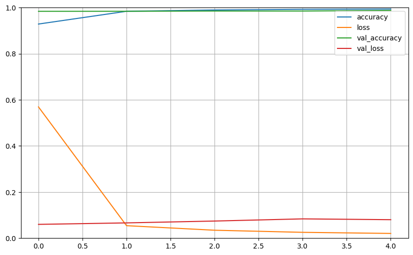

```python
import pandas as pd
import matplotlib.pyplot as plt

def plot_training_history(history):
    pd.DataFrame(history.history).plot(figsize=(10, 6))
    plt.grid(True)
    plt.gca().set_ylim(0, 1)
    plt.show()

plot_training_history(history)
```

The attribute `history.history` is simply a dictionary. You can use this fact to splice together multiple histories.

```python
history.history
```

```
{'accuracy': [0.9287962913513184,
  0.9841111302375793,
  0.9897962808609009,
  0.9926296472549438,
  0.9938703775405884],
 'loss': [0.5693318247795105,
  0.05420711264014244,
  0.0344376303255558,
  0.02534768544137478,
  0.020535223186016083],
 'val_accuracy': [0.984000027179718,
  0.98416668176651,
  0.9851666688919067,
  0.9851666688919067,
  0.9878333210945129],
 'val_loss': [0.0598810538649559,
  0.06628599017858505,
  0.07431024312973022,
  0.0837208554148674,
  0.08015633374452591]}
```

# Visualizing what a CNN does

Keras makes it simple to look at the outputs of each layer of a NN. Here we will look at the outputs of the convolutional and pooling layers, as they are 2-d objects.

The following image is part of the test set.

```python
# The image to plot.
image = 560
```

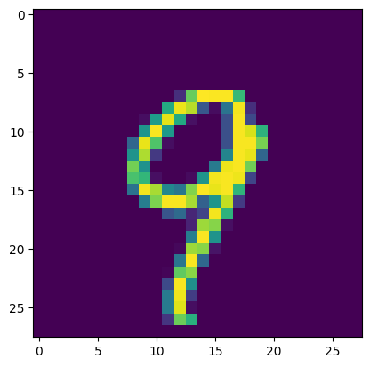

```python
import matplotlib.pyplot as plt

plt.imshow(X_test[image])
plt.show()
```

Now we will build a Keras model that computes the outputs of the pairs of convolutional layers and pooling layers of our CNN. These are all the layers up to the flattening layer that feeds into the dense layers.

```python
layer_names = []
for layer in model.layers[0:6]:
    print(layer.name)
    layer_names.append(layer.name)
```

```
input_layer
conv2d
max_pooling2d
conv2d_1
max_pooling2d_1
conv2d_2
```

```python
from tensorflow.keras import models

# Extract the outputs of the pairs of convolutional and pooling layers.
layer_outputs = [layer.output for layer in model.layers[0:6]]
print(len(layer_outputs))

# Create a model that will return these outputs, given the model input.
activation_model = models.Model(inputs=model.input, outputs=layer_outputs)
print(len(activation_model.layers))
```

```
6
6
```

```python
from tensorflow import keras
from tensorflow.keras import layers

layer_outputs = []
layer_names = []
for layer in model.layers:
    if isinstance(layer, (layers.Conv2D, layers.MaxPooling2D)):
        layer_outputs.append(layer.output)
        layer_names.append(layer.name)
activation_model = keras.Model(inputs=model.input, outputs=layer_outputs)
```

We use the new model's `predict()` method to run the test set through the new model.

```python
# This will return a list of Numpy arrays, one array per
# activation layer.
activations = activation_model.predict(X_test)
print(len(activations))
```

```
313/313 ━━━━━━━━━━━━━━━━━━━━ 1s 4ms/step
5
```

```python
first_layer_activation = activations[1]
print(first_layer_activation.shape)
```

```
(10000, 13, 13, 32)
```

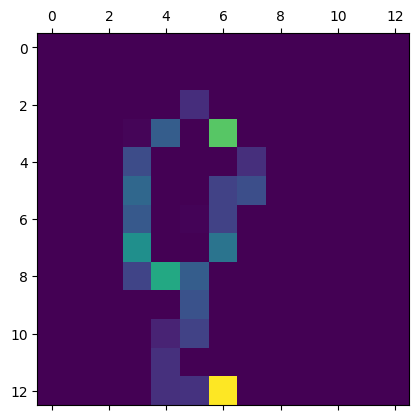

```python
import matplotlib.pyplot as plt

plt.matshow(first_layer_activation[image, :, :, 4], cmap='viridis')
plt.show()
```

Now let's look at all of the outputs.

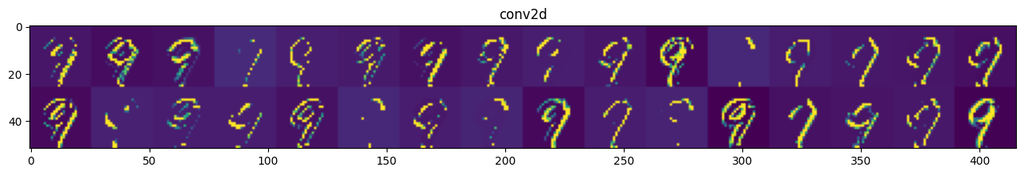

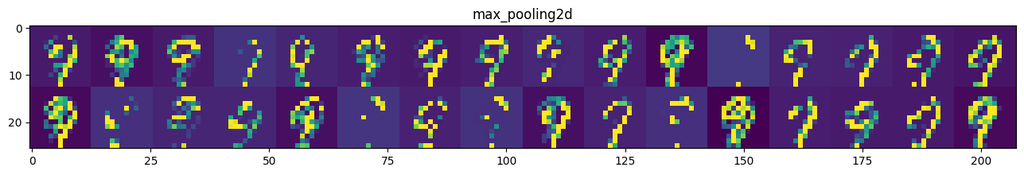

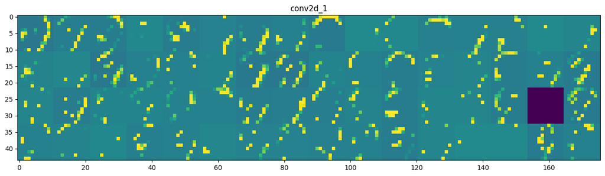

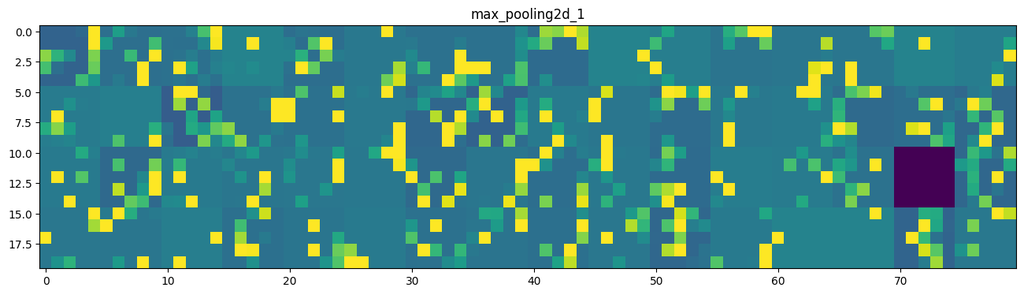

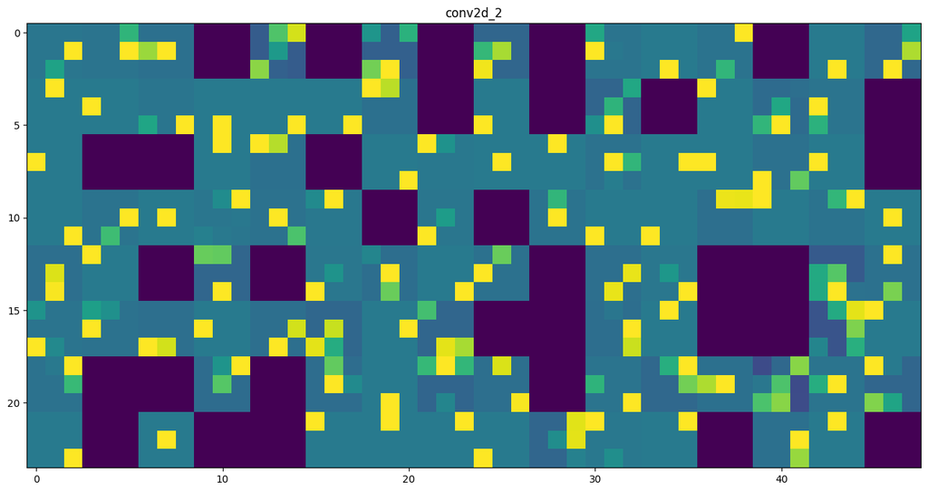

```python
images_per_row = 16

# Now let's display our feature maps.
for layer_name, layer_activation in zip(layer_names, activations):
    # This is the number of features in the feature map.
    n_features = layer_activation.shape[-1]

    # The feature map has shape (1, size, size, n_features).
    size = layer_activation.shape[1]

    # Tile the activation channels in this matrix.
    n_cols = n_features // images_per_row
    display_grid = np.zeros((size * n_cols, images_per_row * size))

    # Tile each filter into a big horizontal grid.
    for col in range(n_cols):
        for row in range(images_per_row):
            channel_image = layer_activation[image,
                                             :, :,
                                             col * images_per_row + row]
            # Post-process the feature to make it visually palatable
            channel_image -= channel_image.mean()
            channel_image /= channel_image.std()
            channel_image *= 64
            channel_image += 128
            channel_image = np.clip(channel_image, 0, 255).astype('uint8')
            display_grid[col * size : (col + 1) * size,
                         row * size : (row + 1) * size] = channel_image

    # Display the grid.
    scale = 1. / size
    plt.figure(figsize=(scale * display_grid.shape[1],
                        scale * display_grid.shape[0]))
    plt.title(layer_name)
    plt.grid(False)
    plt.imshow(display_grid, aspect='auto', cmap='viridis')

plt.show()
```

The first convolutional layer seems to contain horizontal and diagonal edge detectors.

The second convolutional layer seems to further decompose the digit.

However, after we exit the third convolutional layer it is not clear what we are looking at (at least not to me!).

The blank tiles are interesting – these are filters that did not activate. This means that the features those filters detect were not present in this particular image.

# Softmax and cross-entropy

Recall that probabilities lie in the range $0$ to $1$, and for a particular instance the sum over all the classes must be $1$. How do we ensure our neural network outputs possess these properties?

Suppose $(z_{1}, \ldots, z_{m})$ are the outputs of the last hidden layer. We can convert these into probability estimates using the **softmax function**. The softmax function is defined via $$ y_{k} = \frac{e^{z_{k}}}{\sum_{j=1}^{m} e^{z_{j}}}. $$ This function is smooth and behaves like a probability. Clearly we have $0 < y_{k} < 1$ for all $k$, and if we sum over all the possible classes, we obtain $1$: $$ y_{1} + \cdots + y_{m} = \sum_{k=1}^{m} \frac{e^{z_{k}}}{\sum_{j=1}^{m} e^{z_{j}}} = \frac{\sum_{k=1}^{m} e^{z_{k}}}{\sum_{j=1}^{m} e^{z_{j}}} = 1. $$

Define $$ c_{ik} = \begin{cases} 1 & \mbox{if training case $i$ belongs to class $k$,} \\ 0 & \mbox{otherwise.} \end{cases} $$ Let $(y_{1}(x;W), \ldots, y_{m}(x; W))$ be the softmax probability estimates the neural network computes given the input $x$ and model parameters $W$. The likelihood associated with our training set is $$ \prod_{x^{(i)} \in {\mathcal T}} \prod_{k=1}^{m} y_{k}(x^{(i)}; W)^{c_{ik}}. $$ Taking the logarithm we obtain the log-likelihood $$ \sum_{x^{(i)} \in {\mathcal T}} \sum_{k=1}^{m} c_{ik} \log y_{k}(x^{(i)}; W). $$ For each $i$, the quantity $$ - \sum_{k=1}^{m} c_{ik} \log y_{k}(x^{(i)}; W) $$ is called the **cross-entropy** of $c$ and $y$. We see that maximizing the log-likelihood for our neural networks is equivalent to minimizing the cross-entropy.

Observe that since $0 < y_{k} < 1$ the cross-entropy is always positive. We can ensure that the cross-entropy has a lower bound of zero by subtracting a constant: $$ - \sum_{k=1}^{m} \left( c_{ik} \log y_{k}(x^{(i)}; W) - c_{ik} \log c_{ik} \right). $$ This function is minimized when $y_{k}(x^{(i)}; W) = c_{kk}$ with minimum value 0, which makes it easier to monitor the progress of the optimization since we know where we would like ideally to end up.